# MammalBrain

Prajwal Vijendra

September 19, 2018

## Mammal Brain

```r
library(tidyverse)
library(lattice)

mammalbrain <-  read.csv("Dataset/Ex0912.csv")

head(mammalbrain)
```

```
##   X           Species Brain  Body Gestation Litter
## 1 1            Quokka 17.50 3.500        26    1.0
## 2 2          Hedgehog  3.50 0.930        34    4.6
## 3 3        Tree shrew  3.15 0.150        46    3.0
## 4 4  Elephant shrew I  1.14 0.049        51    1.5
## 5 5 Elephant shrew II  1.37 0.064        46    1.5
## 6 6             Lemur 22.00 2.100       135    1.0
```

```r
summary(mammalbrain)
```

```
##        X                     Species       Brain
##  Min.   : 1.00   Aardvark        : 1   Min.   :   0.45
##  1st Qu.:24.75   Acouchis        : 1   1st Qu.:  12.60
##  Median :48.50   African elephant: 1   Median :  74.00
##  Mean   :48.50   Agoutis         : 1   Mean   : 218.98
##  3rd Qu.:72.25   Axis deer       : 1   3rd Qu.: 260.00
##  Max.   :96.00   Badger          : 1   Max.   :4480.00
##                  (Other)         :90
##       Body            Gestation         Litter
##  Min.   :   0.017   Min.   : 16.0   Min.   :1.00
##  1st Qu.:   2.075   1st Qu.: 63.0   1st Qu.:1.00
##  Median :   8.900   Median :133.5   Median :1.20
##  Mean   : 108.328   Mean   :151.3   Mean   :2.31
##  3rd Qu.:  94.750   3rd Qu.:226.2   3rd Qu.:3.20
##  Max.   :2800.000   Max.   :655.0   Max.   :8.00
##
```

Taking the log values of Brain, Body, Gestation, Litter and then comutuing the summary of the dataframe.

```r
mammalbrain$logbrain = log(mammalbrain$Brain)

mammalbrain$logbody = log(mammalbrain$Body)

mammalbrain$loggestation = log(mammalbrain$Gestation)

mammalbrain$loglitter = log(mammalbrain$Litter)

summary(mammalbrain)
```

```
##        X                     Species       Brain
##  Min.   : 1.00   Aardvark        : 1   Min.   :   0.45
##  1st Qu.:24.75   Acouchis        : 1   1st Qu.:  12.60
##  Median :48.50   African elephant: 1   Median :  74.00
##  Mean   :48.50   Agoutis         : 1   Mean   : 218.98
##  3rd Qu.:72.25   Axis deer       : 1   3rd Qu.: 260.00
##  Max.   :96.00   Badger          : 1   Max.   :4480.00
##                  (Other)         :90
##       Body            Gestation         Litter        logbrain
##  Min.   :   0.017   Min.   : 16.0   Min.   :1.00   Min.   :-0.7985
##  1st Qu.:   2.075   1st Qu.: 63.0   1st Qu.:1.00   1st Qu.: 2.5333
##  Median :   8.900   Median :133.5   Median :1.20   Median : 4.3040
##  Mean   : 108.328   Mean   :151.3   Mean   :2.31   Mean   : 3.8646
##  3rd Qu.:  94.750   3rd Qu.:226.2   3rd Qu.:3.20   3rd Qu.: 5.5607
##  Max.   :2800.000   Max.   :655.0   Max.   :8.00   Max.   : 8.4074
##
##     logbody         loggestation     loglitter
##  Min.   :-4.0745   Min.   :2.773   Min.   :0.0000
##  1st Qu.: 0.7297   1st Qu.:4.143   1st Qu.:0.0000
##  Median : 2.1858   Median :4.894   Median :0.1823
##  Mean   : 2.1305   Mean   :4.713   Mean   :0.5976
##  3rd Qu.: 4.5507   3rd Qu.:5.422   3rd Qu.:1.1617
##  Max.   : 7.9374   Max.   :6.485   Max.   :2.0794
##
```

Taking the subset of the dtaframe to include just the log values.

```r
sub.mammalbrain = subset(mammalbrain, select=c("logbrain", "logbody", "loggestation", "loglitter"))

summary(sub.mammalbrain)
```

```
##     logbrain          logbody         loggestation     loglitter
##  Min.   :-0.7985   Min.   :-4.0745   Min.   :2.773   Min.   :0.0000
##  1st Qu.: 2.5333   1st Qu.: 0.7297   1st Qu.:4.143   1st Qu.:0.0000
##  Median : 4.3040   Median : 2.1858   Median :4.894   Median :0.1823
##  Mean   : 3.8646   Mean   : 2.1305   Mean   :4.713   Mean   :0.5976
##  3rd Qu.: 5.5607   3rd Qu.: 4.5507   3rd Qu.:5.422   3rd Qu.:1.1617
##  Max.   : 8.4074   Max.   : 7.9374   Max.   :6.485   Max.   :2.0794
```

Scatter plots for log mammal brain vs log of body, log of gestation, log of litter

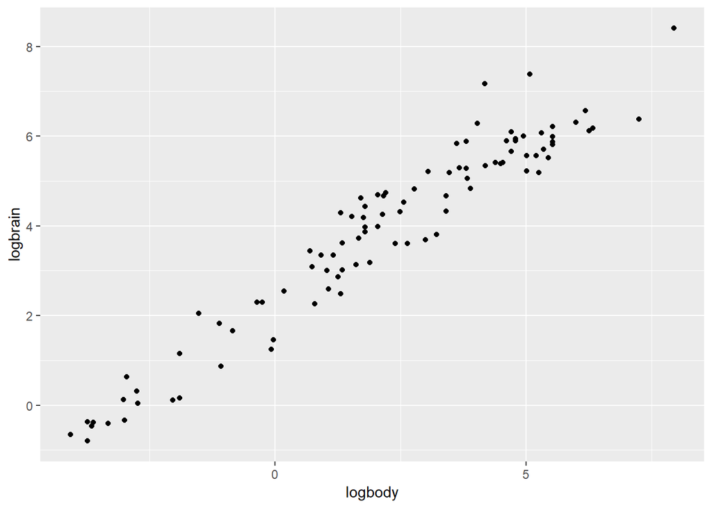

```r
ggplot(data = sub.mammalbrain) + geom_point(mapping = aes(y = logbrain, x = logbody))
```

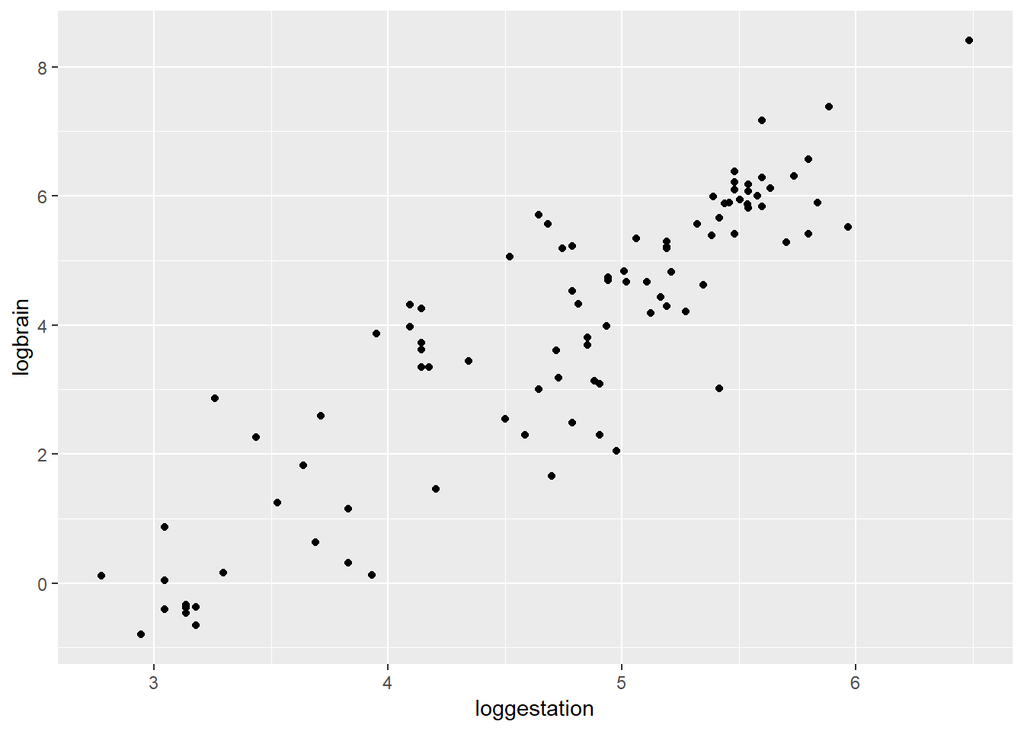

```r
ggplot(data = sub.mammalbrain) + geom_point(mapping = aes(y = logbrain, x = loggestation))
```

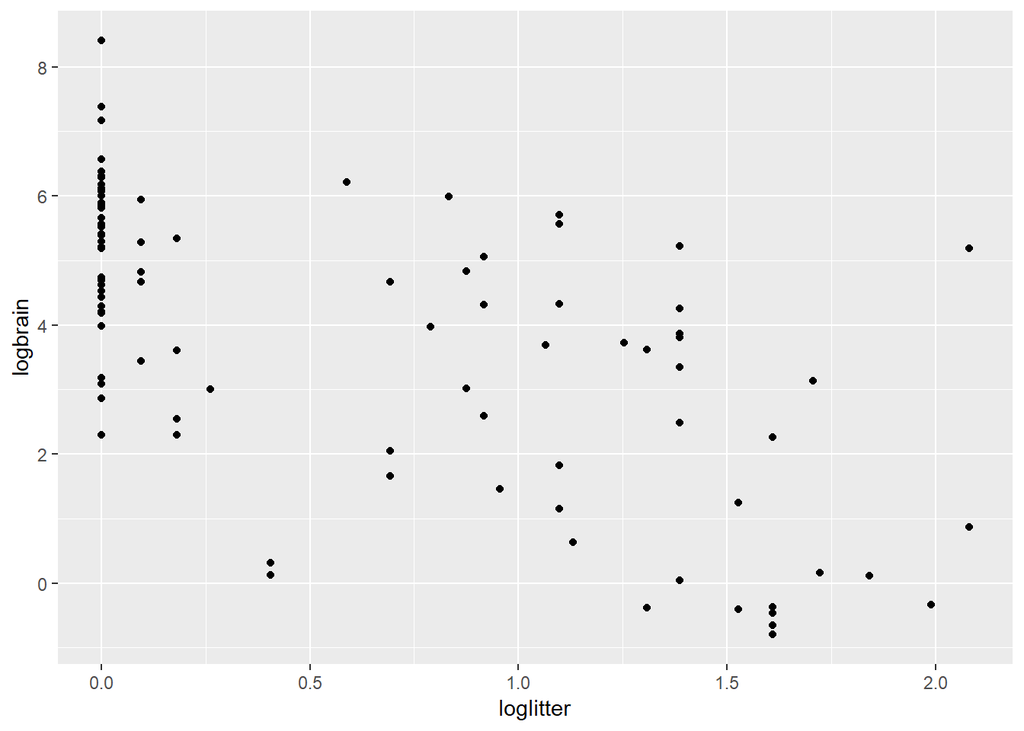

```r
ggplot(data = sub.mammalbrain) + geom_point(mapping = aes(y = logbrain, x = loglitter))
```

The scatter plot for logbrain vs logbody shows a linear relationship with acceptable constant variance.

The scatter plot for logbrain vs loggestation shows a linear relationship with acceptable constant variance.

The scatter plot for logbrain vs loglitter shows a weak linear relationship.

Lets create a multiple linear regresson model of log brain weight on log body, log gestation and log litter.

```r
regbrain = lm(logbrain ~ logbody + loggestation + loglitter, data= sub.mammalbrain)

summary(regbrain)
```

```
##
## Call:
## lm(formula = logbrain ~ logbody + loggestation + loglitter, data = sub.mammalbrain)
##
## Residuals:
##      Min       1Q   Median       3Q      Max
## -0.95415 -0.29639 -0.03105  0.28111  1.57491
##
## Coefficients:
##              Estimate Std. Error t value Pr(>|t|)
## (Intercept)   0.85482    0.66167   1.292  0.19962
## logbody       0.57507    0.03259  17.647  < 2e-16 ***
## loggestation  0.41794    0.14078   2.969  0.00381 **
## loglitter    -0.31007    0.11593  -2.675  0.00885 **
## ---
## Signif. codes:  0 '***' 0.001 '**' 0.01 '*' 0.05 '.' 0.1 ' ' 1
##
## Residual standard error: 0.4748 on 92 degrees of freedom
## Multiple R-squared:  0.9537, Adjusted R-squared:  0.9522
## F-statistic: 631.6 on 3 and 92 DF,  p-value: < 2.2e-16
```

```r
confint(regbrain)
```

```
##                   2.5 %      97.5 %
## (Intercept)  -0.4593167  2.16896055
## logbody       0.5103490  0.63979373
## loggestation  0.1383359  0.69754827
## loglitter    -0.5403124 -0.07982996
```

```r
1.1^confint(regbrain)
```

```
##                  2.5 %    97.5 %
## (Intercept)  0.9571668 1.2296432
## logbody      1.0498439 1.0628764
## loggestation 1.0132721 1.0687433
## loglitter    0.9498062 0.9924203
```

We can see that the coefficients of logbody is 0.57507 and SE is 0.03259, coeffcient of loggestation is 0.4179 and SE is 0.14078, coeffcient of loglitter is -0.31007 and SE is 0.11593.

The R-squared is 0.9537 and Standard Error is 0.4748.

We can interpret the model by: Body Weight: If there is a 10% increase in the body weight, then multiplicative factor associated with median brain weight is 1.05634 (1.1^0.57507). The 95% confidence interval for the mutiplicative factor is between 1.0498439 and 1.0628764.

Gestatiton: If there is a 10% increase in the gestation, then multiplicative factor associated with median brain weight is 1.040638 (1.1^0.41794). The 95% confidence interval for the mutiplicative factor is between 1.0132721 and 1.0687433.

Litter: If there is a 10% increase in the litter, then multiplicative factor associated with median brain weight is 0.9708796 (1.1^-0.31007). The 95% confidence interval for the mutiplicative factor is between 0.9498062 and 0.9924203.

Scatter plot for Litter vs logbrain

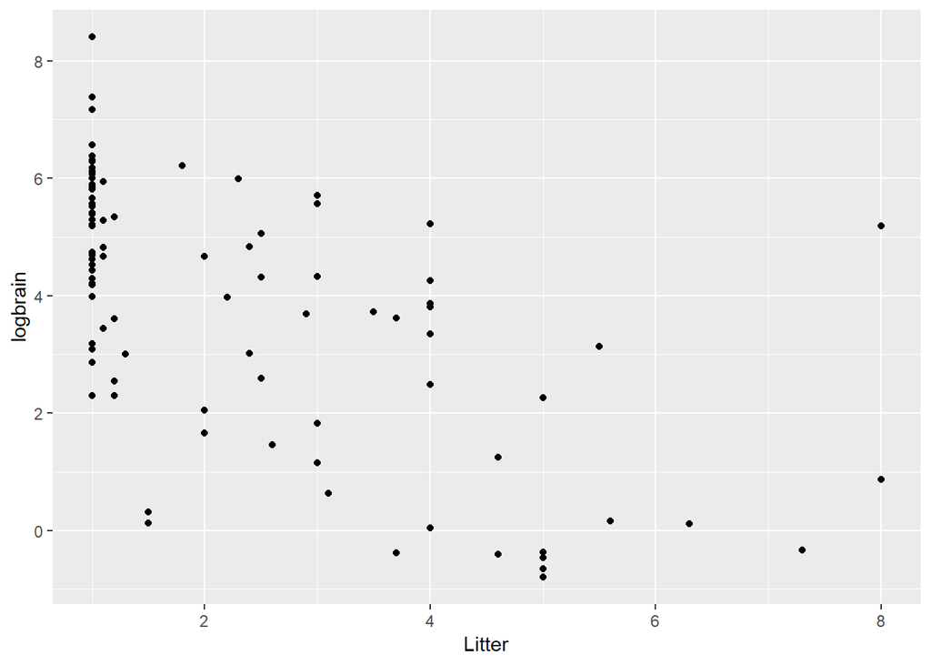

```r
ggplot(data = mammalbrain) + geom_point(mapping = aes(x = Litter, y = logbrain))
```

```r
cor(mammalbrain$logbrain, mammalbrain$Litter)
```

```
## [1] -0.6119879
```

```r
cor(mammalbrain$logbrain, mammalbrain$loglitter)
```

```
## [1] -0.6429762
```

Looking at the scatter plots of logbrain vs loglitter and logbrain vs Litter and comparing the correlation values of both, we can see that logbrain and loglitter has a slighly better linear relation than the logbrain and litter.

Creating a multiple linear relationship model of logbrain on logbody, loggestation and Litter.

```r
regbrain2 = lm(logbrain ~ logbody + loggestation + Litter, data= mammalbrain)

summary(regbrain2)
```

```
##
## Call:
## lm(formula = logbrain ~ logbody + loggestation + Litter, data = mammalbrain)
##
## Residuals:
##      Min       1Q   Median       3Q      Max
## -0.93895 -0.27922 -0.00929  0.28646  1.59743
##
## Coefficients:
##              Estimate Std. Error t value Pr(>|t|)
## (Intercept)   0.82338    0.66206   1.244  0.21678
## logbody       0.57455    0.03264  17.601  < 2e-16 ***
## loggestation  0.43964    0.13698   3.210  0.00183 **
## Litter       -0.11038    0.04227  -2.611  0.01053 *
## ---
## Signif. codes:  0 '***' 0.001 '**' 0.01 '*' 0.05 '.' 0.1 ' ' 1
##
## Residual standard error: 0.4756 on 92 degrees of freedom
## Multiple R-squared:  0.9535, Adjusted R-squared:  0.952
## F-statistic: 629.4 on 3 and 92 DF,  p-value: < 2.2e-16
```

```r
confint(regbrain2)
```

```
##                   2.5 %      97.5 %
## (Intercept)  -0.4915254  2.13829063
## logbody       0.5097143  0.63937813
## loggestation  0.1675856  0.71169994
## Litter       -0.1943220 -0.02643223
```

```r
exp(-0.11038)
```

```
## [1] 0.8954938
```

We can see that the coefficients of logbody is 0.57455 and SE is 0.03264, coeffcient of loggestation is 0.43964 and SE is 0.13698, coeffcient of Litter is -0.11038 and SE is 0.04227.

The R-squared is 0.9535 and Standard Error is 0.4756.

Litter: If there is a 1 unit increase in the Litter, then multiplicative factor associated with median brain weight is 0.8954. The 95% confidence interval for the mutiplicative factor is between 0.8233 and 0.9739

Plotting the residual plots for regbrain against the independent variables.

[figure not shown]

```r
par(mfrow = c(2,2))

plot(y = regbrain$residual, x=mammalbrain$loglitter, ylab = "Residuals", xlab = "Rate", main = "Plot of residuals versus Log of Litter")
abline(0,0)
plot(y = regbrain$residual, x=mammalbrain$logbody, ylab = "Residuals", xlab = "Rate", main = "Plot of residuals versus Log of Body")
abline(0,0)
plot(y = regbrain$residual, x=mammalbrain$loggestation, ylab = "Residuals", xlab = "Rate", main = "Plot of residuals versus Log of Brain")
abline(0,0)
```

Plotting the residual plots for regbrain2 against the independent variables.

[figure not shown]

```r
par(mfrow = c(2,2))

plot(y = regbrain2$residual, x=mammalbrain$Litter, ylab = "Residuals", xlab = "Rate", main = "Plot of residuals versus Litter")
abline(0,0)
plot(y = regbrain2$residual, x=mammalbrain$logbody, ylab = "Residuals", xlab = "Rate", main = "Plot of residuals versus Log of Body")
abline(0,0)
plot(y = regbrain2$residual, x=mammalbrain$loggestation, ylab = "Residuals", xlab = "Rate", main = "Plot of residuals versus Log of Brain")
abline(0,0)
```

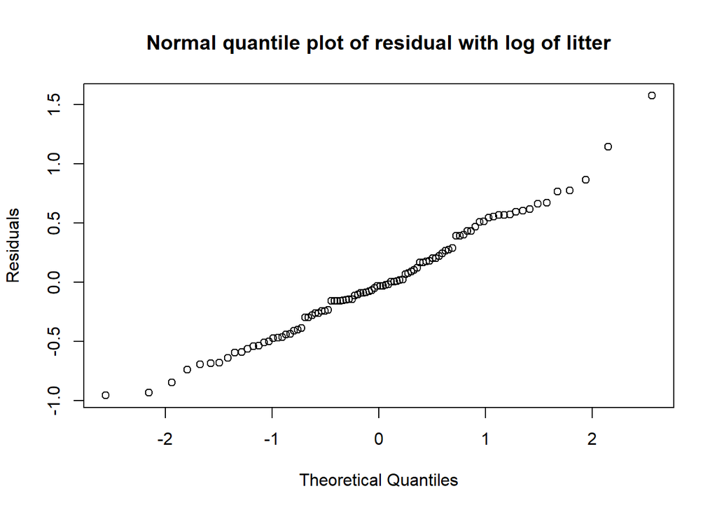

```r
qqnorm(regbrain$residuals, ylab = "Residuals", main = "Normal quantile plot of residual with log of litter")
```

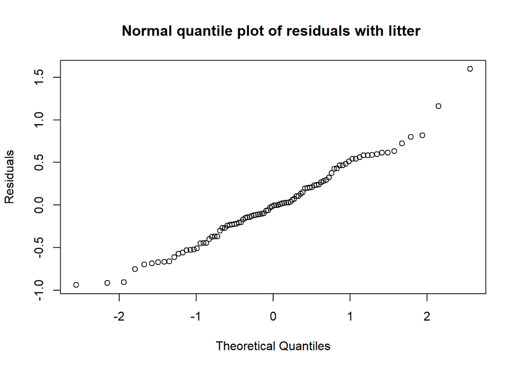

```r
qqnorm(regbrain2$residuals, ylab = "Residuals", main = "Normal quantile plot of residuals with litter ")
```

The residual plots for both the model (model with natural scale for litter and log scale for litter) has more or less the same constant variance. The qq plot for the model with log litter is sligthly better than model with natural scale. Yet, I would prefer the model with natural scale of litter because it is easier to interpret the model.